# Cryptocurrency Market Analysis

Ian Evans

## Introduction

This study looks at the relationship between the cryptocurrency market, the NASDAQ, DJIA, bond market, and ten-year U.S. Treasury Bond yields. My first hypothesis that I want to test is whether or not the cryptocurrency market and the stock market are positively statistically significant or vice versa. I have personally observed that a good day in the stock market is a bad one for the cyrptocurrency market and vice versa so bulding a regression model will help test this. The second hypothesis that I have is whether or not cryptocurrency market is growing faster than the stock market. I will test this hypothesis by taking a look at the volumes of the respective markets. The third and final hypothesis I have is that cryptocurrency percent changes are positively higher than interest rate changes over the long run. I will run three regressions to test these three statements.

## Data Dictionary

Cryptodataset:

date: a categorical variable where the date can only be a selection of one day within a year.

open: a numerical variable that is inputted based on the observed opening price that day in the respective market.

high: a numerical variable that is inputted based on the observed highest price that day in the respective market.

low: a numerical variable that is inputted based on the observed lowest price that day in the respective market.

close: a numerical variable that is inputted based on the observed closing price that day in the respective market.

volume: a numerical variable that is inputted based on the total volume of assets in the market(Dow Jones Industrial Average, Nasdaq, Bitcoin)

percentchange_open: a numerical variable that was calculated based on the change between the observed opening price that day and the day before it.

market: a categorical variable that is inputted based on the market that the value is representing.

## Methods

For this study I collected data from various financial databases. To find the historical data of DJIA, BTC, and NASDAQ I went to Yahoo finance and selected the timeline that I wanted.I decided to begin with the start of Bitcoin so July, 6, 2010 is the first date that I begin collecting from the DJIA and the NASDAQ. In order to get the interest rates and yields on the U.S 10-year bond I went to the Bloomberg database in the Robins School of Business to collect this information on an excel spreadsheet and then filter it and add the respective dates.

For the btc_usd dataset it was harder to filter because I needed to delete dates for weekends and holidays because the other markets do not report on those days. Because I desire to achieve a fair comparison of my data I then went in and filter the data so the numbers would be correctly formatted without any arbitrary dollar signs or dashes that could mess up the code. Lastly, I calculated the variable percentchange_open which represents the percent change in the open price from that day and the day before, in the respective market.

*the three different cryptodatasets are just variations of the first cryptodataset. Cryptodataset2 organizes the data by month and cryptodataset3 adds the 10-year U.S. Treasury Bond rates

## Visualizations

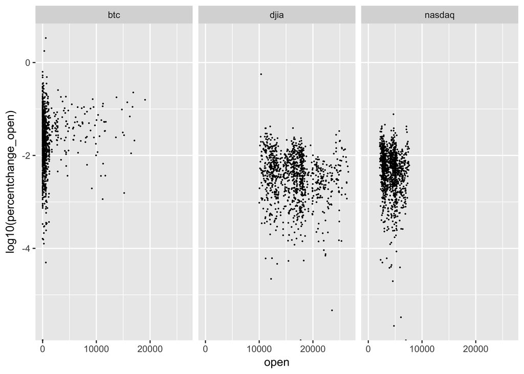

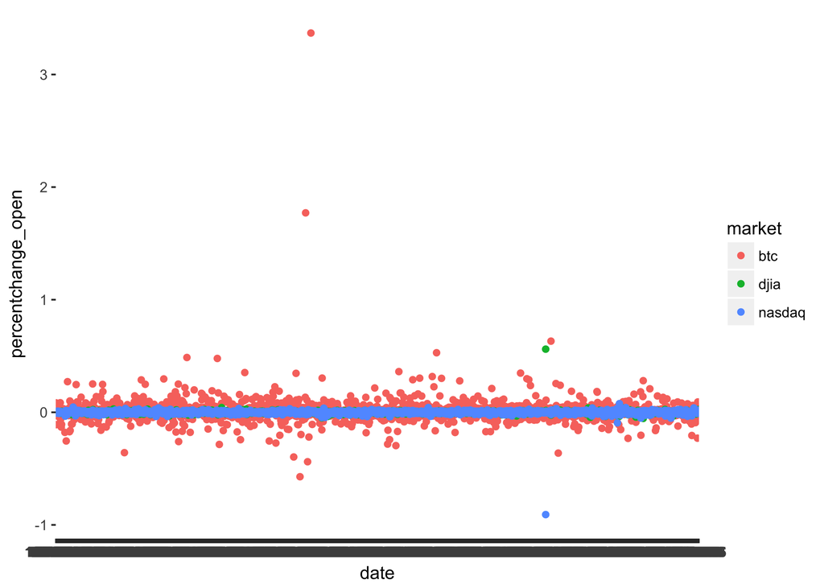

This graph shows us the percent change in opening price of the respective markets over the last 8 years. The graph shows us that BTC has maintained a more volatile nature compared to the DJIA and the NASDAQ whose data points crowd closely around zero. Little variation in price change percentages leaves little room for speculation and arbitrage in the DJIA and the Nasdaq whereas greater variation in Bitcoin allows for more seculation and arbitrage however in the long run it is also mean reverting to zero.

## Results

```
##
## Call:
## lm_basic(formula = volume ~ 1 + market, data = cryptodataset)
##
## Residuals:
##        Min         1Q     Median         3Q        Max
## -1.780e+09 -8.884e+07 -5.797e+07  4.900e+07  1.991e+09
##
## Coefficients:
##               Estimate     2.5 %    97.5 %
## (Intercept)  9.085e+07 8.112e+07 1.006e+08
## marketdjia   7.224e+07 5.854e+07 8.595e+07
## marketnasdaq 1.689e+09 1.675e+09 1.703e+09
##
## Residual standard error: 217300000 on 5502 degrees of freedom
##   (330 observations deleted due to missingness)
## Multiple R-squared:  0.9238, Adjusted R-squared:  0.9238
## F-statistic: 3.337e+04 on 2 and 5502 DF,  p-value: < 2.2e-16
```

```
##
## Call:
## lm_basic(formula = percentchange_open ~ 1 + market, data = cryptodataset)
##
## Residuals:
##     Min      1Q  Median      3Q     Max
## -0.9086 -0.0086 -0.0003  0.0061  3.3583
##
## Coefficients:
##               Estimate     2.5 % 97.5 %
## (Intercept)   0.010105  0.007125  0.013
## marketdjia   -0.009340 -0.013555 -0.005
## marketnasdaq -0.009928 -0.014143 -0.006
##
## Residual standard error: 0.06704 on 5832 degrees of freedom
## Multiple R-squared:  0.004584,   Adjusted R-squared:  0.004242
## F-statistic: 13.43 on 2 and 5832 DF,  p-value: 1.52e-06
```

```
##
## Call:
## lm_basic(formula = percentchange_open ~ 1 + market, data = cryptodataset3)
##
## Residuals:
##     Min      1Q  Median      3Q     Max
## -0.5822 -0.0179 -0.0038  0.0145  3.3583
##
## Coefficients:
##              Estimate     2.5 % 97.5 %
## (Intercept)  0.010105  0.006486  0.014
## markettyb   -0.009889 -0.015009 -0.005
##
## Residual standard error: 0.0814 on 3884 degrees of freedom
##   (4 observations deleted due to missingness)
## Multiple R-squared:  0.003678,   Adjusted R-squared:  0.003422
## F-statistic: 14.34 on 1 and 3884 DF,  p-value: 0.000155
```

## Conclusions

The first regression table was constructed with the hopes of exploring whether or not an inference can be made between the realtionship of Bitcoin and the major stock markets. My hypothesis is that the Bitcoin market and stock markets have a negative correlation. The first table displayed shows the mean of the volume of the Bitcoin market versus the Dow Jones Industrial Average and the Nasdaq. When we look at the volume of Bitcoin in the last 8 years it is not surprising that both the NASDAQ and DJIA still have significantly higher volumes. What is surprising is that over the last 8 years the mean volume of Bitcoin has amassed a volume of more than half the size of the DJIA. All three markets’ confidence intervals do not contain zero, therefore they are all significantly postive. Although this do not tell us much besides that all three are growing positively in volume terms, we can see that Bitcoin has established itself as a multi-million dollar market with a volume that the DJIA saw not too long ago. It appears that my hypothesis is rejected in this case but further research may shed more light on this area.

From my research and analysis I have observed that the volume of the three markets may be generally positive and growing based on the past 8 years, however the linear regression model may not be the best fit for the percentage change comparisons between Bitcoin prices, Stock markets prices, and interests rates. We need to look into differential equations to best model these marekts’ behaviors.

## References

https://finance.yahoo.com/ https://www.bloomberg.com/